# Kmeans - Segmentation- clustering

Problem Statement: A Fleet Management company is planning to provide safe & Efficient Driving training to the drivers. They also want to provide benefits to the drivers based on their performance. The Company wants to group their drivers into different segments based on the Speeding Behaviour and the Distance they drive per day. The Company wants you to build a Segentation/clustering Model which will group their drivers into groups.

Data: You have been provided with teh necessary data as a .csv file.

1.Import Data

```python
import pandas as pd
from sklearn.cluster import KMeans
import warnings
warnings.simplefilter('ignore')
```

```python
df = pd.read_csv('C:\\Users\\Arun61\\Desktop\\DATA SCIENCE\\Megha Files\\25.11.18\\KMeans\\KMeans\\Python\\Kmeans.csv')
```

2.Explorartory of Data

```python
df.head()
```

|  | Driver_ID | Distance_Feature | Speeding_Feature |
| --- | --- | --- | --- |
| 0 | 3423311935 | 71.24 | 28 |
| 1 | 3423313212 | 52.53 | 25 |
| 2 | 3423313724 | 64.54 | 27 |
| 3 | 3423311373 | 55.69 | 22 |
| 4 | 3423310999 | 54.58 | 25 |

```python
df.describe()
```

|  | Driver_ID | Distance_Feature | Speeding_Feature |
| --- | --- | --- | --- |
| count | 4.000000e+03 | 4000.000000 | 4000.000000 |
| mean | 3.423312e+09 | 76.041523 | 10.721000 |
| std | 1.154845e+03 | 53.469563 | 13.708543 |
| min | 3.423310e+09 | 15.520000 | 0.000000 |
| 25% | 3.423311e+09 | 45.247500 | 4.000000 |
| 50% | 3.423312e+09 | 53.330000 | 6.000000 |
| 75% | 3.423313e+09 | 65.632500 | 9.000000 |
| max | 3.423314e+09 | 244.790000 | 100.000000 |

```python
len(df)
```

```
4000
```

Visulaization

```python
import seaborn as sns
```

Plot 1

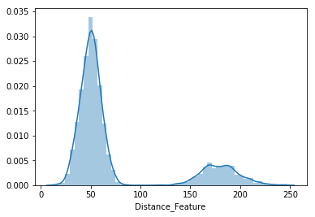

```python
sns.distplot(df['Distance_Feature'])
```

plot 2

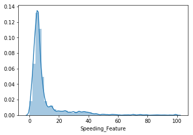

```python
sns.distplot(df['Speeding_Feature'])
```

Mostly 10 miles/hour few crossing 40miles/hour

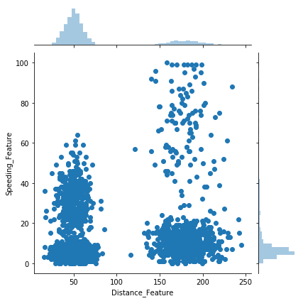

```python
sns.jointplot('Distance_Feature','Speeding_Feature',data=df)
```

Building the Model

Note: No train Test Data Split as this is an unsupervised Learning Algorithm

2 segments

```python
Kmeans = KMeans(n_clusters=2)
Kmeans.fit(df.drop('Driver_ID',axis=1))
```

```
KMeans(algorithm='auto', copy_x=True, init='k-means++', max_iter=300,
    n_clusters=2, n_init=10, n_jobs=1, precompute_distances='auto',
    random_state=None, tol=0.0001, verbose=0)
```

To find center

```python
Kmeans.cluster_centers_
```

```
array([[180.017075  ,  18.29      ],
       [ 50.04763438,   8.82875   ]])
```

Cluster no as label 2 - new colmn

```python
label = Kmeans.labels_
df['label_2']=label
print(df)
```

```
       Driver_ID  Distance_Feature  Speeding_Feature  label_2
0     3423311935             71.24                28        1
1     3423313212             52.53                25        1
2     3423313724             64.54                27        1
3     3423311373             55.69                22        1
4     3423310999             54.58                25        1
5     3423313857             41.91                10        1
6     3423312432             58.64                20        1
7     3423311434             52.02                 8        1
8     3423311328             31.25                34        1
9     3423312488             44.31                19        1
10    3423311254             49.35                40        1
11    3423312943             58.07                45        1
12    3423312536             44.22                22        1
13    3423311542             55.73                19        1
```

[output cut: 49 more lines]

```python
print(label)
set(df['label_2'])
```

```
[1 1 1 ... 0 0 0]
```

```
{0, 1}
```

two groups have been formed

# Plots the clusters and Analyse

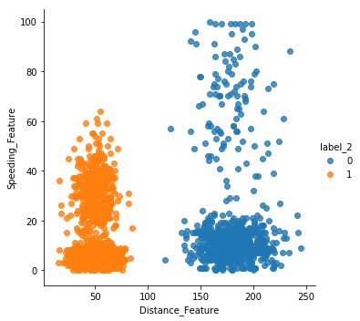

```python
sns.lmplot('Distance_Feature','Speeding_Feature',data=df,fit_reg=False,hue="label_2")
```

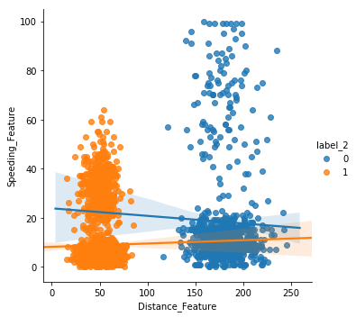

```python
sns.lmplot('Distance_Feature','Speeding_Feature',data=df,fit_reg=True,hue="label_2")
```

# 4 Groups

```python
Kmeans = KMeans(n_clusters=4)
Kmeans.fit(df.drop(['Driver_ID','label_2'],axis=1))
```

```
KMeans(algorithm='auto', copy_x=True, init='k-means++', max_iter=300,
    n_clusters=4, n_init=10, n_jobs=1, precompute_distances='auto',
    random_state=None, tol=0.0001, verbose=0)
```

```python
Kmeans.cluster_centers_
```

```
array([[ 49.99263253,   5.20447169],
       [177.83509615,  70.28846154],
       [ 50.40482436,  32.36533958],
       [180.34311782,  10.52011494]])
```

```python
label_4 = Kmeans.labels_
print(label_4)
```

```
[2 2 2 ... 3 3 3]
```

```python
set(label_4)
```

```
{0, 1, 2, 3}
```

```python
df['label_4']=label_4
df.head()
```

|  | Driver_ID | Distance_Feature | Speeding_Feature | label_2 | label_4 |
| --- | --- | --- | --- | --- | --- |
| 0 | 3423311935 | 71.24 | 28 | 1 | 2 |
| 1 | 3423313212 | 52.53 | 25 | 1 | 2 |
| 2 | 3423313724 | 64.54 | 27 | 1 | 2 |
| 3 | 3423311373 | 55.69 | 22 | 1 | 2 |
| 4 | 3423310999 | 54.58 | 25 | 1 | 2 |

# visualization for 4 Group

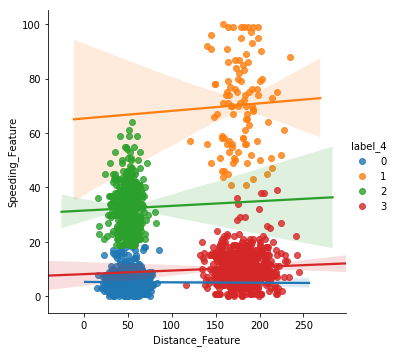

```python
sns.lmplot('Distance_Feature','Speeding_Feature',data=df,fit_reg=True,hue="label_4")
```

# Elbow method for effcient groups

```python
sse={}

# No of clusters
for k in range(1,20):
    Kmeans = KMeans(n_clusters=k).fit(df.drop(['Driver_ID','label_2','label_4'],axis=1))
    sse[k] = Kmeans.inertia_

# Save Groups
groups=list(sse.keys())
errors=list(sse.values())

#Create dataframe
error_df=pd.DataFrame(list(zip(groups,errors)),columns=['groups','errors'])
error_df.head()
```

|  | groups | errors |
| --- | --- | --- |
| 0 | 1 | 1.218463e+07 |
| 1 | 2 | 1.316421e+06 |
| 2 | 3 | 9.926341e+05 |
| 3 | 4 | 7.196015e+05 |
| 4 | 5 | 5.346652e+05 |

# Elbow Plot

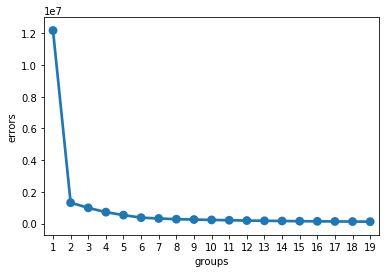

```python
sns.pointplot(x='groups',y='errors',data = error_df)
```

From the Graph two groups can be form but error is getting constant after 6 groups so we can try for 5 and 6 groups

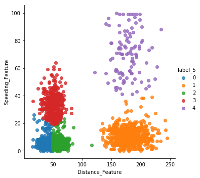

```python
Kmeans=KMeans(n_clusters=5)
Kmeans.fit(df.drop(['Driver_ID','label_2','label_4'],axis=1))
df['label_5']=Kmeans.labels_
sns.lmplot('Distance_Feature', 'Speeding_Feature', data=df, fit_reg=False, hue="label_5")
```

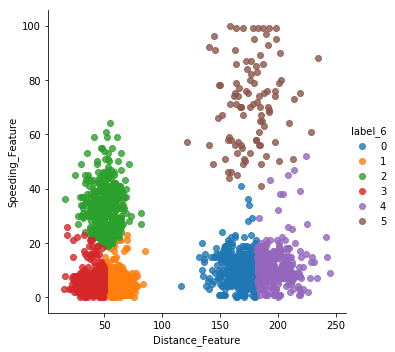

```python
Kmeans=KMeans(n_clusters=6)
Kmeans.fit(df.drop(['Driver_ID','label_2','label_4','label_5'],axis=1))
df['label_6']=Kmeans.labels_
sns.lmplot('Distance_Feature', 'Speeding_Feature', data=df, fit_reg=False, hue="label_6")
```

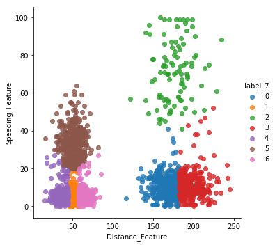

```python
Kmeans=KMeans(n_clusters=7)
Kmeans.fit(df.drop(['Driver_ID','label_2','label_4','label_5','label_6'],axis=1))
df['label_7']=Kmeans.labels_
sns.lmplot('Distance_Feature', 'Speeding_Feature', data=df, fit_reg=False, hue="label_7")
```

# conclusion

Hence using the K Means Algorithm, the given set of 4000 Drivers have been classified into 2,4,5,6 and 7 Groups. Upon receiving confirmation from the client on number of groups to fix, we shall freeze the Model.